# PEC3_Modelos_victimas_agresores

http://scikit.ml/api/skmultilearn.html

El módulo skmultilearn.adapt implementa enfoques de adaptación de algoritmos para la clasificación multi etiqueta (multilabel).

Los métodos de adaptación de algoritmos para la clasificación multilabel se concentran en adaptar los algoritmos de clasificación de una sola etiqueta al caso de múltiples etiquetas, generalmente mediante cambios en las funciones de costo/decisión.

```python
# MLkNN

from skmultilearn.adapt import MLkNN
from scipy.sparse import csr_matrix


classifier = MLkNN(k=7)

classifier.fit(X_train_a, y_train_a.to_numpy())

predictions = classifier.predict(X_test_a)

print("F1_score = ",f1_score(y_test_a.to_numpy(),predictions,average='macro'))
```

```
F1_score =  0.5036462287712984
```

```python
print(classification_report(y_test_a,predictions,target_names=categories,zero_division = 1))
```

```
                   precision    recall  f1-score   support

     EchoViolence       0.49      0.49      0.49      1014
EmotionalViolence       0.52      0.55      0.53      1005
 PhisycalViolence       0.49      0.51      0.50       960
   SexualViolence       0.49      0.50      0.49       966
VicariousViolence       0.52      0.48      0.50      1010
    CiberViolence       0.51      0.52      0.51      1032
WorkPlaceViolence       0.51      0.49      0.50      1032

        micro avg       0.50      0.50      0.50      7019
        macro avg       0.50      0.50      0.50      7019
     weighted avg       0.50      0.50      0.50      7019
      samples avg       0.51      0.51      0.47      7019
```

```python
# Matriz de Confusión

cm = multilabel_confusion_matrix(y_test_a,predictions)
print(cm)
```

```
[[[464 522]
  [522 492]]

 [[491 504]
  [457 548]]

 [[518 522]
  [468 492]]

 [[524 510]
  [485 481]]

 [[542 448]
  [522 488]]

 [[454 514]
  [497 535]]

 [[489 479]
  [526 506]]]
```

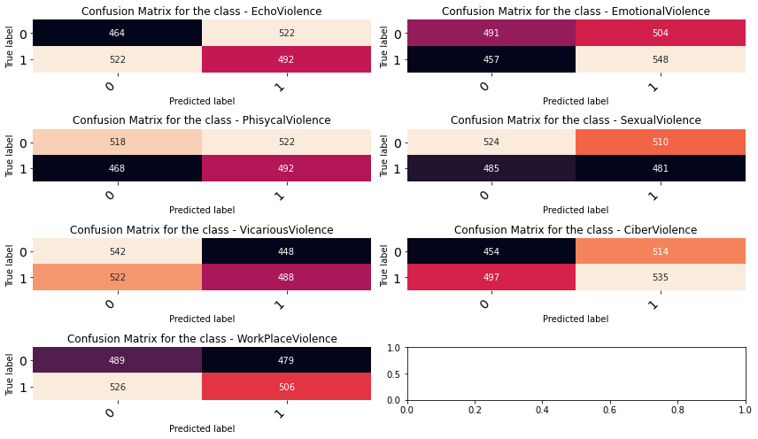

```python
fig, ax = plt.subplots(4, 2, figsize=(12, 7))

for axes, cfs_matrix, label in zip(ax.flatten(), cm, categories):
        print_confusion_matrix(cfs_matrix, axes, label, ["N", "Y"])

fig.tight_layout()
plt.show()
```

```python
# BRkNNaClassifier

from skmultilearn.adapt import BRkNNaClassifier

classifier = BRkNNaClassifier(k=3)

classifier.fit(X_train_a, y_train_a.to_numpy())

predictions = classifier.predict(X_test_a)

print("F1_score = ",f1_score(y_test_a.to_numpy(),predictions,average='macro'))
```

```
F1_score =  0.49814273493517425
```

```python
print(classification_report(y_test_v,predictions,target_names=categories,zero_division = 1))
```

```
                   precision    recall  f1-score   support

     EchoViolence       0.51      0.49      0.50      1023
EmotionalViolence       0.51      0.55      0.53       996
 PhisycalViolence       0.49      0.48      0.49      1001
   SexualViolence       0.50      0.51      0.51      1001
VicariousViolence       0.50      0.48      0.49      1003
    CiberViolence       0.47      0.51      0.49       969
WorkPlaceViolence       0.52      0.51      0.51      1017

        micro avg       0.50      0.50      0.50      7010
        macro avg       0.50      0.50      0.50      7010
     weighted avg       0.50      0.50      0.50      7010
      samples avg       0.50      0.51      0.46      7010
```

```python
# Matriz de Confusión

cm = multilabel_confusion_matrix(y_test_a,predictions)
print(cm)
```

```
[[[485 501]
  [522 492]]

 [[462 533]
  [458 547]]

 [[519 521]
  [497 463]]

 [[494 540]
  [494 472]]

 [[518 472]
  [517 493]]

 [[457 511]
  [511 521]]

 [[498 470]
  [512 520]]]
```

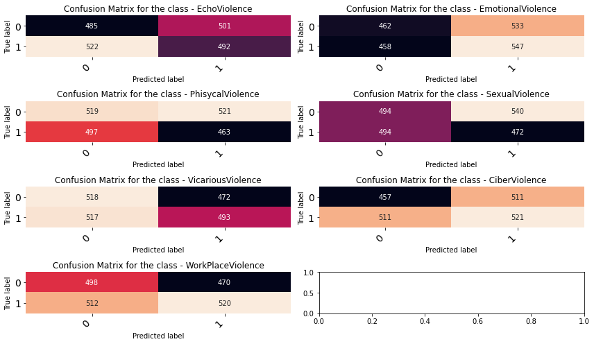

```python
fig, ax = plt.subplots(4, 2, figsize=(12, 7))

for axes, cfs_matrix, label in zip(ax.flatten(), cm, categories):
        print_confusion_matrix(cfs_matrix, axes, label, ["N", "Y"])

fig.tight_layout()
plt.show()
```

```python
# MLTSVM Twin multi-Label Support Vector Machines

#Wei-Jie Chen, Yuan-Hai Shao, Chun-Na Li, Nai-Yang Deng, MLTSVM: A novel twin support vector machine to multi-label learning,
#Pattern Recognition,Volume 52,2016,Pages 61-74,ISSN 0031-3203

parameters = {'c_k': [2**i for i in range(-5, 5, 2)]}

score = 'f1_macro'

grid = GridSearchCV(MLTSVM(), parameters, scoring=score)

y_sparse = csr_matrix(y_train_a)

X_sparse = csr_matrix(X_train_a)

grid.fit(X_sparse, y_sparse)
```

```
GridSearchCV(estimator=MLTSVM(),
             param_grid={'c_k': [0.03125, 0.125, 0.5, 2, 8]},
             scoring='f1_macro')
```

```python
print(grid.best_score_)
print(grid.best_params_)
print(grid.best_estimator_)
```

```
0.6638608111583049
{'c_k': 0.03125}
MLTSVM(c_k=0.03125)
```

```python
clf = MLTSVM(c_k = 0.03125)
```

```python
# Lo entrenamos
clf.fit(X_sparse, y_sparse)
```

```python
# Calculamos la predicción
predictions = clf.predict(X_test_a)

y_pred_train = clf.predict(X_train_a)
```

```python
y_sparse_test = csr_matrix(y_test_a.to_numpy())
```

```python
print('y_test_score F1: ',f1_score(y_sparse_test, predictions, average='macro'))
print('y_train_score F1:',f1_score(y_train_a, y_pred_train, average='macro'))
```

```
y_test_score F1:  0.6699062166994966
y_train_score F1: 0.6639264823390167
```

```python
print(classification_report(y_sparse_test,predictions,target_names=categories,zero_division = 1))
```

```
                   precision    recall  f1-score   support

     EchoViolence       0.51      1.00      0.67      1018
EmotionalViolence       0.48      1.00      0.65       969
 PhisycalViolence       0.50      1.00      0.67      1007
   SexualViolence       0.51      1.00      0.67      1015
VicariousViolence       0.52      1.00      0.68      1036
    CiberViolence       0.50      1.00      0.67      1009
WorkPlaceViolence       0.50      1.00      0.67       998

        micro avg       0.50      1.00      0.67      7052
        macro avg       0.50      1.00      0.67      7052
     weighted avg       0.50      1.00      0.67      7052
      samples avg       0.50      1.00      0.65      7052
```

**4.5 MULTILABEL DEEP LEARNING**

```python
# Multilabel DNN

# Creamos un modelo single class

from keras.models import Sequential
from keras.layers import Dense

def create_model_single_class(input_dim, output_dim):
    # create model
    model = Sequential()
    model.add(Dense(12, input_dim=input_dim, activation='relu'))
    model.add(Dense(8, activation='relu'))
    model.add(Dense(output_dim, activation='sigmoid'))
    # Compile model
    model.compile(loss='binary_crossentropy', optimizer='adam', metrics=['accuracy'])
    return model
```

```python
from skmultilearn.ext import Keras
import arff

# Utilizamos en método Problem Transformation (BinariRelevance) que convierte un problema Multilabel en uno single label single class

KERAS_PARAMS = dict(epochs=10, batch_size=100, verbose=0)

clf = BinaryRelevance(classifier=Keras(create_model_single_class, False, KERAS_PARAMS), require_dense=[True,True])
clf.fit(X_train_a, y_train_a)
result = clf.predict(X_test_a)
```

```python
print("F1_score = ",f1_score(y_test_a.to_numpy(),result,average='macro'))
```

```
F1_score =  0.4797272094026477
```

```python
print(classification_report(y_test_a,result,target_names=categories, zero_division = 1))
```

```
                   precision    recall  f1-score   support

     EchoViolence       0.52      0.38      0.44      1014
EmotionalViolence       0.50      0.64      0.56      1005
 PhisycalViolence       0.48      0.44      0.46       960
   SexualViolence       0.50      0.53      0.51       966
VicariousViolence       0.51      0.35      0.42      1010
    CiberViolence       0.50      0.50      0.50      1032
WorkPlaceViolence       0.52      0.43      0.47      1032

        micro avg       0.50      0.47      0.48      7019
        macro avg       0.50      0.47      0.48      7019
     weighted avg       0.50      0.47      0.48      7019
      samples avg       0.50      0.47      0.44      7019
```

```python
# Matriz de Confusión

cm = multilabel_confusion_matrix(y_test_a,result)
print(cm)
```

```
[[[627 359]
  [630 384]]

 [[360 635]
  [363 642]]

 [[590 450]
  [539 421]]

 [[516 518]
  [457 509]]

 [[650 340]
  [656 354]]

 [[453 515]
  [515 517]]

 [[553 415]
  [586 446]]]
```

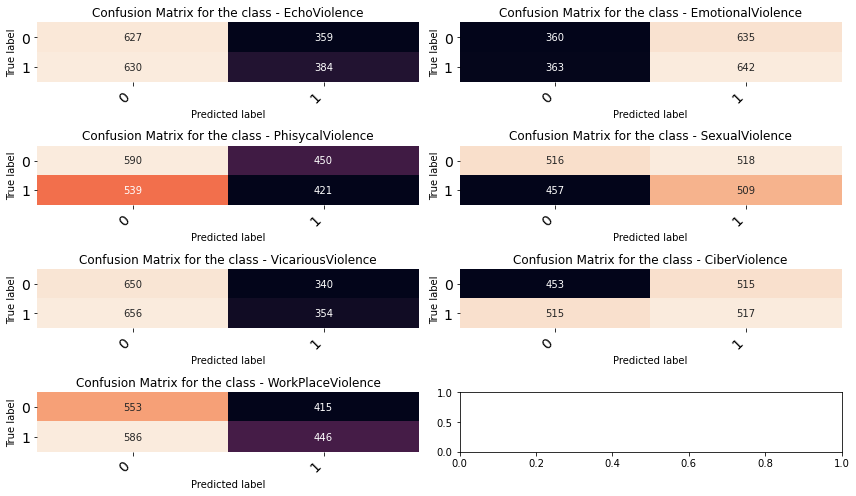

```python
fig, ax = plt.subplots(4, 2, figsize=(12, 7))

for axes, cfs_matrix, label in zip(ax.flatten(), cm, categories):
        print_confusion_matrix(cfs_matrix, axes, label, ["N", "Y"])

fig.tight_layout()
plt.show()
```

**NOTA: Como se puede comprobar, los resultados obtenidos no son alentadores, aún cuando se han probado todo tipo de algoritmos y estrategias y comprobado que los datos están balanceados. Comentar que en el siguiente trabajo, se indica que los conjuntos de datos no balanceados representados por atributos binarios no pueden utilizar bastantes de los algoritmos de Machine Learning estándar de forma óptima**

**También se indica que, a través de experimentos utilizando conjuntos de datos de referencia y conjuntos de datos médicos reales, se observó que un conjunto de datos convertido que consta de características numéricas, es mejor para los métodos de sobremuestreo (las mejoras máximas de precisión y F1_score fueron del 35,11 % y 42,17%, respectivamente). Además, se confirma que la extracción de características y el sobremuestreo contribuyen sinérgicamente a la mejora del rendimiento de la clasificación**

**Kunti Robiatul Mahmudah, Fatma Indriani,Yukiko Takemori-Sakai, Yasunori Iwata, Takashi Wada and Kenji Satou Classification of Imbalanced Data Represented as Binary Features https://mdpi-res.com/d_attachment/applsci/applsci-11-07825/article_deploy/applsci-11-07825-v2.pdf?version=1630033232**

**Agradeceré cualquier tipo de comentario al respecto**

**REFERENCIAS**

**Scikit Learn: Multiclass and multioutput algorithms https://scikit-learn.org/stable/modules/multiclass.html**

**Scikit: Multi-Label Classification in Python http://scikit.ml/**

**Scikit MultiLearn: http://scikit.ml/api/skmultilearn.html**

**Multi-label deep learning with scikit-multilearn: http://scikit.ml/multilabeldnn.html**

**Kunti Robiatul Mahmudah, Fatma Indriani,Yukiko Takemori-Sakai, Yasunori Iwata, Takashi Wada and Kenji Satou Classification of Imbalanced Data Represented as Binary Features https://mdpi-res.com/d_attachment/applsci/applsci-11-07825/article_deploy/applsci-11-07825-v2.pdf?version=1630033232**

**Scikit Learn: sklearn.naive_bayes.MultinomialNB https://scikit-learn.org/stable/modules/generated/sklearn.naive_bayes.MultinomialNB.html**

**TowardsDataScience. Kartik Nooney.Jun 8 2018: Deep dive into multi-label classification..! (With detailed Case Study) https://towardsdatascience.com/journey-to-the-center-of-multi-label-classification-384c40229bff**

**Analytics Vidhyia. Solving Multi-Label Classification problems (Case studies included) https://www.analyticsvidhya.com/blog/2017/08/introduction-to-multi-label-classification/**

**Kaggle. JACK DONG .Multi-Label Classification Simple Example https://www.kaggle.com/code/dongr0510/multi-label-classification-simple-example/notebook**

**Jason Brownlee on August 31, 2020 Machine Learning Mastery. Multi-Label Classification with Deep Learning https://machinelearningmastery.com/multi-label-classification-with-deep-learning/**

**https://www.geeksforgeeks.org/ An introduction to MultiLabel classification https://www.geeksforgeeks.org/an-introduction-to-multilabel-classification/**

**Charles Kariuki September 24 2021 https://www.section.io/ Multi-Label Classification with Scikit-MultiLearn https://www.section.io/engineering-education/multi-label-classification-with-scikit-multilearn/**

**David Ten Multi-label Classification with scikit-multilearn https://xang1234.github.io/multi-label/**

**Scikit Learn Multiclass and multioutput algorithms https://scikit-learn.org/stable/modules/multiclass.html**

**https://www.quora.com/ Which machine learning algorithms are optimal for boolean features? https://www.quora.com/Which-machine-learning-algorithms-are-optimal-for-boolean-features**

**BENCHMARKS IN MULTILABLE CLASSIFICATION https://paperswithcode.com/ : https://paperswithcode.com/task/multi-label-classification**

**Is there a way to do multilabel classification on decision trees using R/Python? https://www.quora.com https://www.quora.com/Is-there-a-way-to-do-multilabel-classification-on-decision-trees-using-R-Python**

**Parameters for Linear Booster https://xgboost.readthedocs.io/ https://xgboost.readthedocs.io/en/latest/parameter.html#learning-task-parameters**

**Rami-Majdoub commented on May 7, 2019 https://github.com/MLTSVM fails with dense matrices as input https://github.com/scikit-multilearn/scikit-multilearn/issues/170**

**https://scikit-learn.org/ Metrics and scoring: quantifying the quality of predictions https://scikit-learn.org/stable/modules/model_evaluation.html**

**Aniruddha Karajgi Nov 1, 2021 Evaluating Multi-label Classifiers https://towardsdatascience.com/ https://towardsdatascience.com/evaluating-multi-label-classifiers-a31be83da6ea**

**Mustafa Murat Arat. Metrics for Multilabel Classification https://mmuratarat.github.io/2020-01-25/multilabel_classification_metrics**

**MURAT KARAKAYA · 2Y AGO Multi Label Model Evaluation https://www.kaggle.com/code/kmkarakaya/multi-label-model-evaluation**

**Learning Task Parameters https://xgboost.readthedocs.io/ https://xgboost.readthedocs.io/en/latest/parameter.html#learning-task-parameters**

**Plot Confusion Matrix for multilabel Classifcation Python https://stackoverflow.com/questions/62722416/plot-confusion-matrix-for-multilabel-classifcation-python**

**Bibor Szabo (May 26, 2020): How to Create a Seaborn Correlation Heatmap in Python? https://medium.com/@szabo.bibor/how-to-create-a-seaborn-correlation-heatmap-in-python-834c0686b88e**

**Medium.com Harikrishnan N B. Dec 10, 2019 Confusion Matrix, Accuracy, Precision, Recall, F1 Score https://medium.com/analytics-vidhya/confusion-matrix-accuracy-precision-recall-f1-score-ade299cf63cd#:~:text=F1%20Score%20becomes%201%20only,0.857%20%2B%200.75)%20%3D%200.799**

**scikit-learn.https://scikit-learn.org/stable/modules/generated/sklearn.metrics.classification_report.html**

**Wei-JieChenaYuan-HaiShaoaChun-NaLiaNai-YangDengb.Science Direct. MLTSVM: A novel twin support vector machine to multi-label learning https://www.sciencedirect.com/science/article/pii/S0031320315003751**